# Statistics Exercise on Beer Ratings

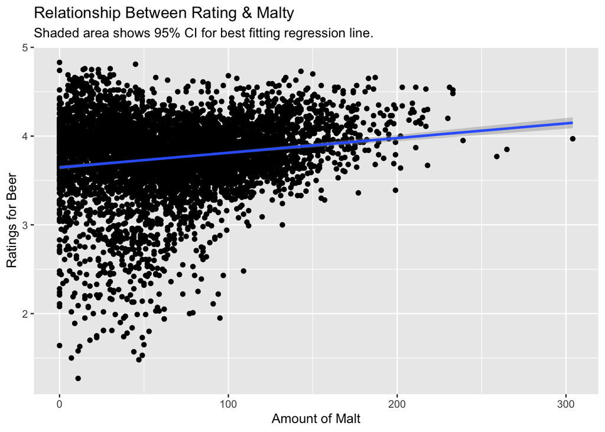

```r
#Plotting the linear model to show the relationship between ratings and malt
ggplot(craft_beer_data, aes(y=rating, x=Malty)) + geom_point() + labs(y="Ratings for Beer", x="Amount of Malt", title = "Relationship Between Rating & Malty", subtitle = "Shaded area shows 95% CI for best fitting regression line.") +  geom_smooth(method=lm)
```

```r
rcorr(as.matrix(select(craft_beer_data, rating, Malty, Sweet)))
```

```
##        rating Malty Sweet
## rating   1.00  0.17  0.29
## Malty    0.17  1.00  0.56
## Sweet    0.29  0.56  1.00
##
## n= 5558
##
##
## P
##        rating Malty Sweet
## rating         0     0
## Malty   0            0
## Sweet   0      0
```

```r
#Both the above plots show that there is a positive trend between rating & sweetness and rating & malt. The r value between rating & Sweet (r = 0.29) and rating & Malty (r = 0.17) indicate the same positive trend. We can further also deduce that these trends are significant since the p value between rating & Sweet (p<0.05) and rating & Malty (p<0.05) is less than the threshold.

#Performing linear regression to see the individual effect of rating & Sweet and rating & Malty
#Individual effect of Sweet on rating
m.rating.by.sweet <- lm(rating~Sweet, data=craft_beer_data)
summary(m.rating.by.sweet)
```

[output not shown]

```
##
## Call:
## lm(formula = rating ~ Sweet, data = craft_beer_data)
##
## Residuals:
##      Min       1Q   Median       3Q      Max
## -2.38229 -0.18594  0.04548  0.26453  1.26267
##
## Coefficients:
##              Estimate Std. Error t value Pr(>|t|)
## (Intercept) 3.5673305  0.0102260  348.85   <2e-16 ***
## Sweet       0.0035970  0.0001585   22.69   <2e-16 ***
## ---
## Signif. codes:  0 '***' 0.001 '**' 0.01 '*' 0.05 '.' 0.1 ' ' 1
##
## Residual standard error: 0.4238 on 5556 degrees of freedom
## Multiple R-squared:  0.08483,    Adjusted R-squared:  0.08467
## F-statistic:   515 on 1 and 5556 DF,  p-value: < 2.2e-16
```

```r
#The beta coefficient between rating & Sweet is 0.0035, which indicates a positive trend. This is a significant relationship due to the high t value and small p value observed, t(5556) = 22.69, p<0.0001.

cbind(coef(m.rating.by.sweet), confint(m.rating.by.sweet))
```

```
##                              2.5 %     97.5 %
## (Intercept) 3.56733052 3.547283485 3.58737755
## Sweet       0.00359705 0.003286319 0.00390778
```

```r
#For every unit increase in sweetness, ratings significantly increase by 0.0035 95% CI [0.0032 - 0.0039]. As 0 does not lie within the 95% CI we can be confident about the  model's estimate of slope between rating and Sweet.

#Individual effect of Malty on rating
m.rating.by.malt <- lm(rating~Malty, data=craft_beer_data)
summary(m.rating.by.malt)
```

```
##
## Call:
## lm(formula = rating ~ Malty, data = craft_beer_data)
##
## Residuals:
##      Min       1Q   Median       3Q      Max
## -2.39491 -0.18416  0.04205  0.26897  1.18330
##
## Coefficients:
##              Estimate Std. Error t value Pr(>|t|)
## (Intercept) 3.6466984  0.0107485   339.3   <2e-16 ***
## Malty       0.0016553  0.0001314    12.6   <2e-16 ***
## ---
## Signif. codes:  0 '***' 0.001 '**' 0.01 '*' 0.05 '.' 0.1 ' ' 1
##
## Residual standard error: 0.4368 on 5556 degrees of freedom
## Multiple R-squared:  0.02778,    Adjusted R-squared:  0.0276
## F-statistic: 158.8 on 1 and 5556 DF,  p-value: < 2.2e-16
```

```r
#The beta coefficient between rating & Malty is 0.0016, which indicates a positive trend. This is a significant relationship due to the high t value and small p value observed, t(5556) = 12.6, p<0.0001.

cbind(coef(m.rating.by.malt), confint(m.rating.by.malt))
```

```
##                               2.5 %      97.5 %
## (Intercept) 3.646698369 3.625627075 3.667769662
## Malty       0.001655323 0.001397774 0.001912873
```

```r
#For every unit increase in malt, ratings significantly increase by 0.0016 95% CI [0.0013 - 0.0019]. As 0 does not lie within the 95% CI we can be confident about the  model's estimate of slope between rating and Malty.

#Performing multi regression to see how this trend is impacted when trying to predict ratings while including ABV value and Sweetness or Malt.

#Combined effect of ABV & Sweet on rating
m.rating.by.abv.sweet <- lm(rating ~ ABV + Sweet, data = craft_beer_data)
summary(m.rating.by.abv.sweet)
```

```
##
## Call:
## lm(formula = rating ~ ABV + Sweet, data = craft_beer_data)
##
## Residuals:
##     Min      1Q  Median      3Q     Max
## -3.6966 -0.1555  0.0461  0.2330  1.0837
##
## Coefficients:
##              Estimate Std. Error t value Pr(>|t|)
## (Intercept) 3.2660727  0.0153742  212.44   <2e-16 ***
## ABV         0.0588357  0.0023316   25.23   <2e-16 ***
## Sweet       0.0019367  0.0001639   11.81   <2e-16 ***
## ---
## Signif. codes:  0 '***' 0.001 '**' 0.01 '*' 0.05 '.' 0.1 ' ' 1
##
## Residual standard error: 0.4014 on 5555 degrees of freedom
## Multiple R-squared:  0.1789, Adjusted R-squared:  0.1786
## F-statistic: 605.3 on 2 and 5555 DF,  p-value: < 2.2e-16
```

```r
#The beta coefficient (slope) between rating & ABV is 0.058, which indicates a positive trend. This is a significant relationship due to the high t value and small p value observed, t(5555) = 25.23, p<0.0001. The slope between rating & Sweet is 0.0019, which also indicates a positive trend. This is also a significant relationship as evidenced by the small p value, t(5555) = 11.81, p<0.0001.

cbind(coef(m.rating.by.abv.sweet), confint(m.rating.by.abv.sweet))
```

```
##                              2.5 %      97.5 %
## (Intercept) 3.266072731 3.23593325 3.296212208
## ABV         0.058835653 0.05426476 0.063406543
## Sweet       0.001936738 0.00161537 0.002258107
```

```r
#When estimating the effect of both ABV and Sweet in the same regression we find that when controlling for other variables, a unit extra of ABV predicts 0.058 95% CI [0.054 - 0.063] extra ratings for beer and a unit increase in sweetness predicts an increase in ratings by 0.0019 95% CI [0.0016 - 0.0022]. We can be confident about our model's estimate as 0 does not lie within either CI.

#Combined effect of ABV & Malty on rating
m.rating.by.abv.malt <- lm(rating ~ ABV + Malty, data = craft_beer_data)
summary(m.rating.by.abv.malt)
```

```
##
## Call:
## lm(formula = rating ~ ABV + Malty, data = craft_beer_data)
##
## Residuals:
##     Min      1Q  Median      3Q     Max
## -4.1243 -0.1523  0.0413  0.2236  1.0658
##
## Coefficients:
##              Estimate Std. Error t value Pr(>|t|)
## (Intercept) 3.2523665  0.0163191 199.298  < 2e-16 ***
## ABV         0.0667503  0.0021896  30.485  < 2e-16 ***
## Malty       0.0009487  0.0001238   7.663 2.13e-14 ***
## ---
## Signif. codes:  0 '***' 0.001 '**' 0.01 '*' 0.05 '.' 0.1 ' ' 1
##
## Residual standard error: 0.4043 on 5555 degrees of freedom
## Multiple R-squared:  0.1671, Adjusted R-squared:  0.1668
## F-statistic: 557.3 on 2 and 5555 DF,  p-value: < 2.2e-16
```

```r
#The beta coefficient (slope) between rating & ABV is 0.066, which indicates a positive trend. This is a significant relationship due to the high t value and small p value observed, t(5555) = 30.48, p<0.0001. The slope between rating & Malty is 0.0009, which also indicates a positive trend. This is also a significant relationship as evidenced by the small p value, t(5555) = 7.66, p<0.0001.

cbind(coef(m.rating.by.abv.malt), confint(m.rating.by.abv.malt))
```

```
##                                 2.5 %      97.5 %
## (Intercept) 3.2523665091 3.2203746585 3.284358360
## ABV         0.0667503129 0.0624577980 0.071042828
## Malty       0.0009486502 0.0007059559 0.001191345
```

```r
#When estimating the effect of both ABV and Malty in the same regression we find that when controlling for other variables, a unit extra of ABV predicts 0.066 95% CI [0.062 - 0.071] extra ratings for beer and a unit increase in malt predicts an increase in ratings by 0.0009 95% CI [0.0007 - 0.0011]. We can be confident about our model's estimate as 0 does not lie within either CI.

#It can be inferred that when looking into the combined effect of ABV & Malty and ABV & Sweet in the same regression, the estimation of slope between rating & ABV, rating & Malty and rating & Sweet has decreased when compared to their individual effect in the estimation of slope, thus the change in the slope is most likely due to multicollinearity between variables ABV, Sweet and Malty.

#Checking if multicollineartiy between variables needs action
vif(m.rating.by.abv.malt)
```

```
##      ABV    Malty
## 1.036336 1.036336
```

```r
vif(m.rating.by.abv.sweet)
```

```
##      ABV    Sweet
## 1.192036 1.192036
```

```r
#Multicollinearity is minimal, since the Variance Inflation Factor for variables in both the main models for ABV & Malt and ABV & Sweet are less than 5.

#Checking to see how this trend changes when including interaction effect between ABV & Sweet and ABV & Malty.
#Interaction effect between ABV & Sweet
m.rating.by.abv.sweet.intr <- lm(rating ~ ABV * Sweet, data = craft_beer_data)
summary(m.rating.by.abv.sweet.intr)
```

```
##
## Call:
## lm(formula = rating ~ ABV * Sweet, data = craft_beer_data)
##
## Residuals:
##     Min      1Q  Median      3Q     Max
## -4.1763 -0.1567  0.0455  0.2331  1.0866
##
## Coefficients:
##               Estimate Std. Error t value Pr(>|t|)
## (Intercept)  3.189e+00  2.433e-02 131.055  < 2e-16 ***
## ABV          7.009e-02  3.598e-03  19.478  < 2e-16 ***
## Sweet        3.448e-03  4.033e-04   8.550  < 2e-16 ***
## ABV:Sweet   -1.997e-04  4.869e-05  -4.101 4.18e-05 ***
## ---
## Signif. codes:  0 '***' 0.001 '**' 0.01 '*' 0.05 '.' 0.1 ' ' 1
##
## Residual standard error: 0.4009 on 5554 degrees of freedom
## Multiple R-squared:  0.1814, Adjusted R-squared:  0.181
## F-statistic: 410.3 on 3 and 5554 DF,  p-value: < 2.2e-16
```

```r
#When estimating the interaction effect between ABV and Sweet, the beta coefficient for ABV:Sweet shows us that there is a negative interaction between ABV and Sweet when predicting rating. This implies for every unit increase in ABV, there is a unit decrease in the value of Sweet by 0.0002.This is a significant interaction effect as implied by the small p value, t(5554) = -4.10, p<0.0001.

cbind(coef(m.rating.by.abv.sweet.intr), confint(m.rating.by.abv.sweet.intr))
```

```
##                                   2.5 %        97.5 %
## (Intercept)  3.1886692461  3.1409715134  3.2363669788
## ABV          0.0700855819  0.0630316312  0.0771395326
## Sweet        0.0034480150  0.0026574678  0.0042385622
## ABV:Sweet   -0.0001996505 -0.0002950955 -0.0001042054
```

```r
#The beta coefficient for ABV:Sweet is -0.0002 95% CI [-0.0002 - -0.00010 ].

#Interaction effect between ABV & Malty
m.rating.by.abv.malt.intr <- lm(rating ~ ABV * Malty, data = craft_beer_data)
summary(m.rating.by.abv.malt.intr)
```

```
##
## Call:
## lm(formula = rating ~ ABV * Malty, data = craft_beer_data)
##
## Residuals:
##     Min      1Q  Median      3Q     Max
## -3.4392 -0.1513  0.0429  0.2279  1.0478
##
## Coefficients:
##               Estimate Std. Error t value Pr(>|t|)
## (Intercept)  3.351e+00  2.547e-02 131.601  < 2e-16 ***
## ABV          5.237e-02  3.590e-03  14.587  < 2e-16 ***
## Malty       -5.863e-04  3.281e-04  -1.787    0.074 .
## ABV:Malty    2.139e-04  4.236e-05   5.049 4.57e-07 ***
## ---
## Signif. codes:  0 '***' 0.001 '**' 0.01 '*' 0.05 '.' 0.1 ' ' 1
##
## Residual standard error: 0.4034 on 5554 degrees of freedom
## Multiple R-squared:  0.1709, Adjusted R-squared:  0.1705
## F-statistic: 381.7 on 3 and 5554 DF,  p-value: < 2.2e-16
```

```r
#When estimating the interaction effect between ABV and Malty, the beta coefficient for ABV:Malty shows us that there is a positive interaction between ABV and Malty when predicting rating.This is a significant interaction effect as implied by the small p value, t(5554) = 5.049, p<0.0001.

cbind(coef(m.rating.by.abv.malt.intr), confint(m.rating.by.abv.malt.intr))
```

```
##                                   2.5 %       97.5 %
## (Intercept)  3.3512296311  3.3013079361 3.401151e+00
## ABV          0.0523664944  0.0453287900 5.940420e-02
## Malty       -0.0005862561 -0.0012294861 5.697383e-05
## ABV:Malty    0.0002139100  0.0001308626 2.969575e-04
```

```r
#The beta coefficient for ABV:Malty is 0.0002 95% CI [0.00013 - 0.0003].

#Since there is an interaction effect between ABV and Malty and ABV and Sweet, using ANOVA to see whether the main model or interaction model for both the relationships should be used to predict rating

#Checking for ABV & Sweet
anova(m.rating.by.abv.sweet, m.rating.by.abv.sweet.intr)
```

```
## Analysis of Variance Table
##
## Model 1: rating ~ ABV + Sweet
## Model 2: rating ~ ABV * Sweet
##   Res.Df    RSS Df Sum of Sq      F    Pr(>F)
## 1   5555 895.21
## 2   5554 892.51  1    2.7022 16.816 4.178e-05 ***
## ---
## Signif. codes:  0 '***' 0.001 '**' 0.01 '*' 0.05 '.' 0.1 ' ' 1
```

```r
#Adding the interaction effect between ABV and Sweet significantly improves the fit of the model to predict the rating of the beer, F(1,5554) = 16.8, p<0.0001.

#Checking for ABV and Malty
anova(m.rating.by.abv.malt, m.rating.by.abv.malt.intr)
```

```
## Analysis of Variance Table
##
## Model 1: rating ~ ABV + Malty
## Model 2: rating ~ ABV * Malty
##   Res.Df    RSS Df Sum of Sq      F    Pr(>F)
## 1   5555 908.10
## 2   5554 903.95  1    4.1499 25.497 4.571e-07 ***
## ---
## Signif. codes:  0 '***' 0.001 '**' 0.01 '*' 0.05 '.' 0.1 ' ' 1
```

```r
#Adding the interaction effect between ABV and Malt significantly improves the fit of the model to predict the rating of the beer, F(1,5554) = 25.5, p<0.0001.
```

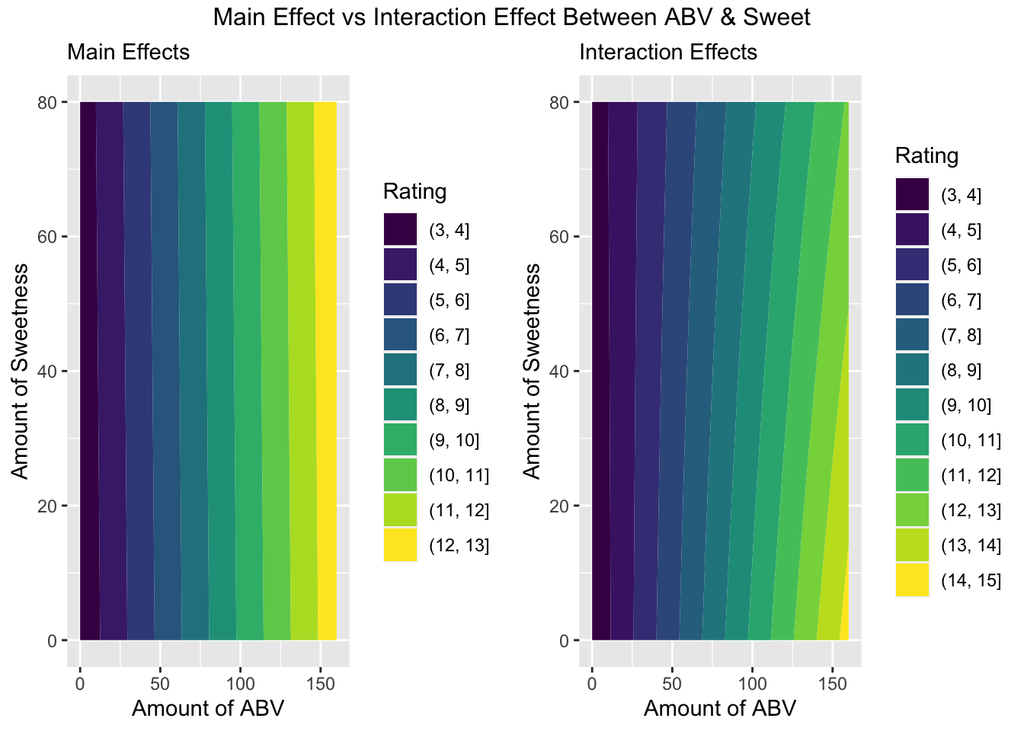

```r
#Visualizing the main effects and interaction effects for ABV and Sweet - purely for visualization purposes doesn't reflect the data in the dataset

intr.surf.data <- tibble(ABV = unlist(expand.grid(seq(0, 160, 2), seq(0, 80, 0.5))[1]),
                         Sweet = unlist(expand.grid(seq(0, 160, 2), seq(0, 80, 0.5))[2]))

intr.surf.data <- mutate(intr.surf.data,
                         main.hat = predict(m.rating.by.abv.sweet, intr.surf.data),
                         intr.hat = predict(m.rating.by.abv.sweet.intr, intr.surf.data))

surf.main <- ggplot(intr.surf.data, aes(ABV, Sweet)) + geom_contour_filled(aes(z = main.hat)) + labs(subtitle = "Main Effects", x = "Amount of ABV", y = "Amount of Sweetness")  + guides(fill=guide_legend(title="Rating"))
surf.intr <- ggplot(intr.surf.data, aes(ABV, Sweet)) + geom_contour_filled(aes(z = intr.hat)) + labs(subtitle = "Interaction Effects", x = "Amount of ABV", y = "Amount of Sweetness")   + guides(fill=guide_legend(title="Rating"))
grid.arrange(surf.main, surf.intr, nrow = 1, top = "Main Effect vs Interaction Effect Between ABV & Sweet")
```

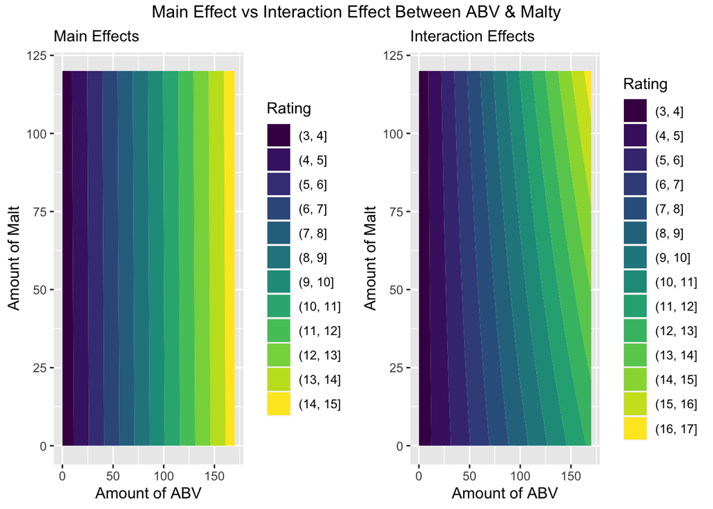

```r
#The above plots clearly show the negative interaction effect between ABV and Sweet, indicating that when sweetness is low the increase in ABV will move up the contours and maximize rating, whereas if sweetness is high the increase in ABV will not move up all contours and maximize rating. Also if ABV is low the increase in sweetness will not move up the contours and maximize rating, if ABV is high the increase in sweetness doesn't necessarily guarantee maximum rating.

#Visualizing the main effects and interaction effects for ABV and Malty - purely for visualization purposes doesn't reflect the data in the dataset

intr.surf.data <- tibble(ABV = unlist(expand.grid(seq(0, 170, 2), seq(0, 120, 2))[1]),
                         Malty = unlist(expand.grid(seq(0, 170, 2), seq(0, 120, 2))[2]))

intr.surf.data <- mutate(intr.surf.data,
                         main.hat = predict(m.rating.by.abv.malt, intr.surf.data),
                         intr.hat = predict(m.rating.by.abv.malt.intr, intr.surf.data))

surf.main <- ggplot(intr.surf.data, aes(ABV, Malty)) + geom_contour_filled(aes(z = main.hat)) + labs(subtitle = "Main Effects", x = "Amount of ABV", y = "Amount of Malt")  + guides(fill=guide_legend(title="Rating"))
surf.intr <- ggplot(intr.surf.data, aes(ABV, Malty)) + geom_contour_filled(aes(z = intr.hat)) + labs(subtitle = "Interaction Effects", x = "Amount of ABV", y = "Amount of Malt")   + guides(fill=guide_legend(title="Rating"))
grid.arrange(surf.main, surf.intr, nrow = 1, top = "Main Effect vs Interaction Effect Between ABV & Malty")
```

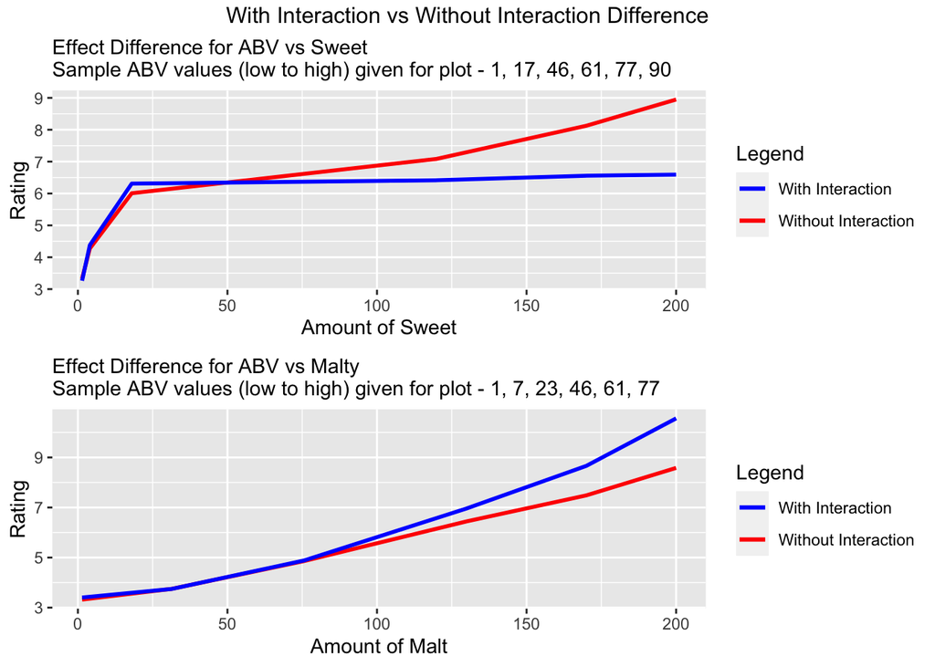

```r
#The above plots clearly show the positive interaction effect between ABV and Malty, indicating that when malt is low the increase in ABV will not move up the contours and maximize rating, whereas if malt is high the increase in ABV will move up all contours and maximize rating. Also if ABV is low the increase in malt will not move up the contours and maximize rating, if ABV is high the increase in malt will guarantee maximum rating.

#Plotting to see the main vs interaction effect difference for ABV vs Sweet and ABV vs Malt. The plots below are purely for visualization and understanding. Sample values are given for plotting.

colors <- c("With Interaction" = "#0000FF", "Without Interaction" = "#FF0000")
#ABV vs Sweet
sample_craft_beer_data<- tibble(ABV = c(1, 17, 46, 61, 77, 90), Sweet = c(1.4, 4, 18, 120, 170, 200))
p2_abv_sweet <- mutate(sample_craft_beer_data,
       main.hat = predict(m.rating.by.abv.sweet, sample_craft_beer_data),
       intr.hat = predict(m.rating.by.abv.sweet.intr, sample_craft_beer_data)) %>%
  ggplot() +
  geom_line(aes(Sweet, main.hat, colour = "Without Interaction"), size = 1) +
  geom_line(aes(Sweet, intr.hat, colour = "With Interaction"), size = 1) +
  labs(y ="Rating", x = "Amount of Sweet", subtitle = "Effect Difference for ABV vs Sweet\nSample ABV values (low to high) given for plot - 1, 17, 46, 61, 77, 90") +
    scale_color_manual(name = "Legend", values = colors)

#The above plot shows how that the main model without interaction and the model with interaction are similar as long as ABV rises and sweetness remains low, but as soon as ABV value & sweetness value keeps rising the ratings being predicted by the model with interaction remain the same showing the negative interaction effect between ABV and Sweet.

#ABV vs Malt
sample_craft_beer_data<- tibble(ABV = c(1, 7, 23, 46, 61, 77), Malty = c(1.4, 31.4, 75.6, 130, 170, 200))
p1_abv_malt <- mutate(sample_craft_beer_data,
       main.hat = predict(m.rating.by.abv.malt, sample_craft_beer_data),
       intr.hat = predict(m.rating.by.abv.malt.intr, sample_craft_beer_data)) %>%
  ggplot() +
  geom_line(aes(Malty, main.hat, colour = "Without Interaction"), size = 1) +
  geom_line(aes(Malty, intr.hat, colour = "With Interaction"), size = 1) +
  labs(y ="Rating", x = "Amount of Malt", subtitle = "Effect Difference for ABV vs Malty\nSample ABV values (low to high) given for plot - 1, 7, 23, 46, 61, 77") +
    scale_color_manual(name = "Legend", values = colors)

#The above plot tells us that main model (without interaction) steadily rises in rating as malt value and ABV value rise, however the slope of the model with interaction rises more steeply as ABV and malt value rise. Thus showing the positive interaction effect between ABV and Malty.

grid.arrange(p2_abv_sweet, p1_abv_malt, ncol = 1, top  = "With Interaction vs Without Interaction Difference")
```

## Report

   Conclusions from the combined effect of ABV & Sweet on rating –
   - We found that when holding the amount of sweetness constant the rating of a beer increases by a statistically significant 0.058 units t(5555) = 25.23, p<0.0001, 95% CI [0.054 - 0.063] for every extra unit of ABV.
   - When controlling the value of ABV, the rating of a beer increases by 0.0019 units 95% CI [0.0016 - 0.0022] for every extra unit of Sweet, which is significantly different from zero t(5555) = 11.81, p<0.0001.

   Conclusions from the combined effect of ABV & Malt on rating –
   - We found that when holding the amount of malt constant the rating of beer increases by a statistically significant 0.066 units t(5555) = 30.48, p<0.0001, 95% CI [0.062 - 0.071] for every extra unit of ABV.
   - When controlling the value of ABV, the rating of beer increases by 0.0009 95% CI [0.0007 - 0.0011] units for every extra unit of Malty, which is significantly different from zero t(5555) = 7.66, p<0.0001.

   Conclusions from including the interaction term for ABV & Sweet –
   - A negative interaction exists between ABV & Sweet. This means that for every unit increase in ABV, there is a decrease in the value of Sweet by 0.0002 units, t(5554) = -4.10, p<0.0001, 95% CI [-0.0002 - -0.00010 ].
   - The interaction is a significant predictor of rating of beer.

   Conclusions from including the interaction term for ABV & Malty –
   - A positive interaction exists between ABV & Malty. This means that for every unit increase in ABV, there is an increase in the value of Malty by 0.0002 units, t(5554) = 5.049, p<0.0001, 95% CI [0.00013 - 0.0003]].
   - This interaction is a significant predictor of rating of beer.

   Thus it is clear that the model analysis should include interaction terms since they’re significant predictors of rating. In addition to this a model comparison test that compares the model with interaction and the model without interaction shows that the overall model fit is significantly improved when interaction terms for ABV & Sweety F(1,5554) = 16.8, p<0.0001 and ABV & Malty F(1,5554) = 25.5, p<0.0001 are included in the analysis.
3. Do the results suggest that beers with higher or lower ABVs should have different flavours if the company is trying to maximise ratings

   This is why higher or lower ABVs should have different flavours if the company is trying to maximize ratings.

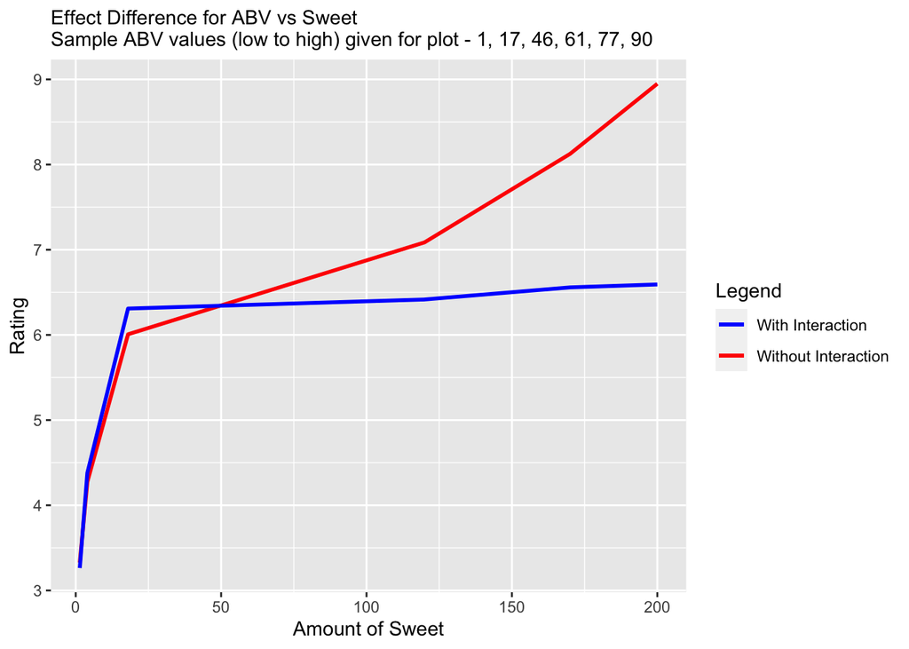

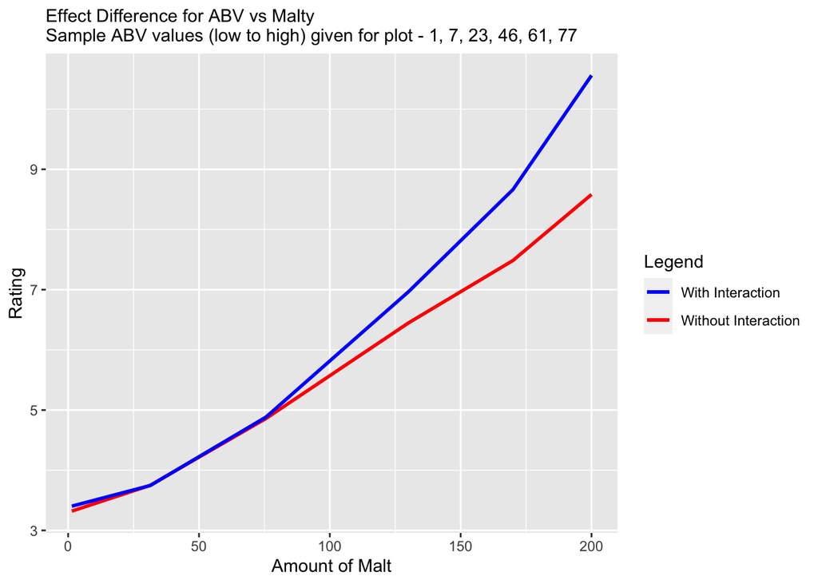

4. What flavourings should the company use more/less of if they are creating a high ABV beer
   - Based on the above graph for ABV vs Sweet, it is clear that for high ABV beers less of Sweet flavour should be used by the company to maximize ratings since there exists a negative interaction between the two.
   - Based on the above graph for ABV vs Malty, it is clear that for high ABV beers more of Malty flavour should be used by the company to maximize ratings since there exists a positive interaction between the two.
5. What flavourings should the company use more/less of if they are creating a low ABV beer
   - Based on the above graph for ABV vs Sweet it is clear that for low ABV beers, there is only a marginal difference in ratings irrespective of whether it is paired with more or less Sweet. But for marginally better ratings the company should use more of Sweet.
   - Similarly based on the above graph for ABV vs Malty it is clear that for low ABV beers pairing it with more of Malty will result in marginally better ratings than pairing it with less of Malty.